# #TidyTuesday Submission

Data Science for Biologists, Spring 2020

Nicholas Paterna

April 5, 2020

### TidyTuesday Week 14

Hi, I am once again attempting to make a figure for #TidyTuesday! I am a student at Rowan University in Biochemistry with *a smidge* of experience in coding thanks to [Dr. Stephanie Spielman](https://twitter.com/stephspiel). R is my first language and I am very happy to be learning it, I hope to work in Bioinformatics one day possibly Medical Genomics. I am open to criticism or helpful tips in trimming my code!!

```r
map_fills <- c("lightgoldenrod1", "orange3", "palevioletred4")
#Assigning the fills I like

tidy_path <- "/Users/nickpaterna/datascience/TidyTuesday/Week_14/"
#This variable will tell the figure where to save when I apply ggsave!

figure_name <- "tidytues_week14.png"
#Rather than re-typing this into ggsave I can just use this!

scale_levels <- c("Low (<100,000)", "Moderate (<= 1 million)", "High (>1 million)")
```

## Avoid Hard-coding!

One of the most important things that my professor stresses is a complete aversion to HARD-CODING, or explicitly re-typing code in a large script. It might not make a lot of sense to apply these practices on a small assignment but the more often I apply it the easier to apply it is in the future! (Also the second visible code chunk gives my submission some more flavor!)

```r
beer_states %>%
  filter(year %in% c(2013, 2019)) %>%
  #Looking at the years I am interested in comparing
  filter(state != "total") %>%
  #Removing the 'total' values to focus on states
  filter(type == "Kegs and Barrels") %>%
  #Only viewing keg data
  mutate(prod_scale = case_when(barrels <= 100000 ~ "Low (<100,000)",
                                barrels > 100000 & barrels <= 1000000 ~ "Moderate (<= 1 million)",
                                barrels > 1000000 ~ "High (>1 million)")) %>%
  mutate(prod_scale = factor(prod_scale, levels = c(scale_levels))) -> keg_data
```

```
## filter: removed 1,560 rows (83%), 312 rows remaining
```

```
## filter: removed 6 rows (2%), 306 rows remaining
```

```
## filter: removed 204 rows (67%), 102 rows remaining
```

```
## mutate: new variable 'prod_scale' with 3 unique values and 0% NA
```

```
## mutate: converted 'prod_scale' from character to factor (0 new NA)
```

```r
head(keg_data)
```

```
## # A tibble: 6 x 5
##   state  year barrels type             prod_scale
##   <chr> <dbl>   <dbl> <chr>            <fct>
## 1 AK     2013  68868. Kegs and Barrels Low (<100,000)
## 2 AK     2019  55454. Kegs and Barrels Low (<100,000)
## 3 AL     2013  11748. Kegs and Barrels Low (<100,000)
## 4 AL     2019   9015. Kegs and Barrels Low (<100,000)
## 5 AR     2013   1078. Kegs and Barrels Low (<100,000)
## 6 AR     2019   3959. Kegs and Barrels Low (<100,000)
```

## Data Wrangling

A big part of my Data Science class is utilizing the many packages in our Tidyverse Tool belt to clean up data. Here, this means filtering out unwanted values and narrowing down the observations of interest for the figure I produced after. I mostly used `dplyr` to help this process but it is still important nonetheless.

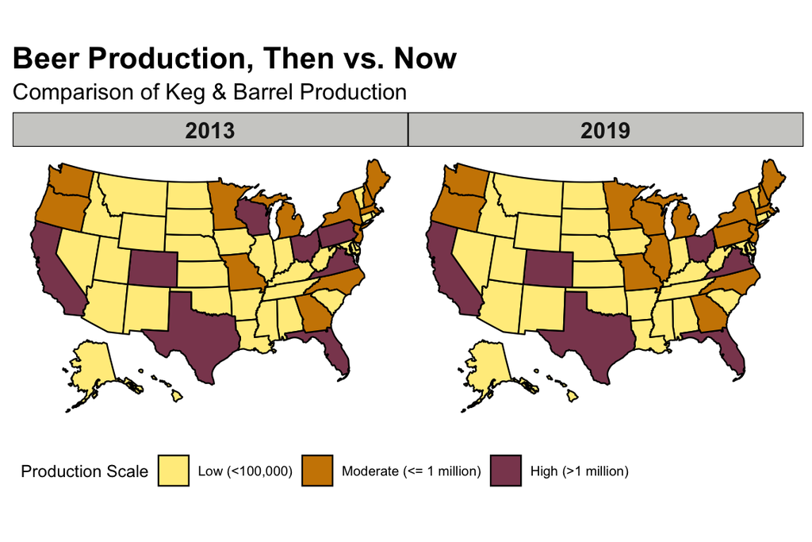

```r
plot_usmap(data = keg_data, values = "prod_scale") +
  #This handy function actually made this map SO easy to make
    scale_fill_manual(values = map_fills) +
    labs(fill = "Production Scale") +
    facet_wrap(~ year) +
    #Compares the two years I filtered out in the wrangling above
    labs(title = "Beer Production, Then vs. Now",
         subtitle = "Comparison of Keg & Barrel Production") +
    theme(plot.title = element_text(size = 16, face = "bold"),
          plot.subtitle = element_text(size = 12),
          legend.position = "bottom",
          strip.text.x = element_text(face = "bold", size = 12),
          strip.background = element_rect(color="black", fill="#cfcfcc")) -> beer_plot

ggsave(paste0(tidy_path, figure_name), beer_plot, height = 4, width = 6)
beer_plot
```

All this past week my data science class finally was back in session so I felt determined to try something new this week for TidyTuesday! My classmates have utilized the `plot_usmap()` function on other submissions so I figured I would test it out! It was a lot of fun to tweak with this function and figure it out, along with this I also worked a lot with the `theme()` function which I typically do not touch in class. I wanted to make something informative but also presentable for Week 14, and I am proud of the result! Fun side note: my boyfriend Brendan chose the fills for this week’s submission!!

I hope you enjoy my plot, you can find this and future entries on my [GitHub](https://github.com/npaterna/datascience/tree/master/TidyTuesday).